# Segmentação de Clientes

# Objetivo

Este projeto tem como objetivo realizar uma segmentação de clientes de um supermercado. Para isso, será utilizado o algoritmo K-Means para agrupar os clientes em grupos de acordo com as suas características.

## Fonte de dados

O conjunto de dados consiste em informações sobre o comportamento de compra de 2.000 indivíduos de uma determinada área ao entrarem em um supermercado. Todos os dados foram recolhidos através dos cartões de fidelização que utilizam no checkout. Os dados foram pré-processados e não há valores ausentes. Além disso, o volume do conjunto de dados foi restrito e anonimizado para proteger a privacidade dos clientes.

Link para o conjunto de dados: https://www.kaggle.com/datasets/dev0914sharma/customer-clustering

### Importando pacotes e versões utilizadas

```python
from platform import python_version
print('Versão da linguagem Python utilizada:', python_version())
```

```
Versão da linguagem Python utilizada: 3.11.5
```

```python
import sklearn
import datetime
import numpy as np
import pandas as pd
import seaborn as sns
import matplotlib as m
import matplotlib.pyplot as plt
from sklearn.cluster import KMeans
```

```python
%reload_ext watermark
%watermark -a "Pedro Henrique Coelho" --iversions
```

```
Author: Pedro Henrique Coelho

numpy     : 1.24.3
matplotlib: 3.7.2
sklearn   : 1.3.0
seaborn   : 0.12.2
pandas    : 2.0.3
```

### Carregando os dados

```python
df = pd.read_csv('Dados/segmentation data.csv', encoding='utf-8')
```

```python
df.shape
```

```
(2000, 8)
```

```python
df.head()
```

|  | ID | Sex | Marital status | Age | Education | Income | Occupation | Settlement size |
| --- | --- | --- | --- | --- | --- | --- | --- | --- |
| 0 | 100000001 | 0 | 0 | 67 | 2 | 124670 | 1 | 2 |
| 1 | 100000002 | 1 | 1 | 22 | 1 | 150773 | 1 | 2 |
| 2 | 100000003 | 0 | 0 | 49 | 1 | 89210 | 0 | 0 |
| 3 | 100000004 | 0 | 0 | 45 | 1 | 171565 | 1 | 1 |
| 4 | 100000005 | 0 | 0 | 53 | 1 | 149031 | 1 | 1 |

### Dicionário dos Dados

**Variável - Tipo de dado - Descrição**

- ID - numérico - Identificador único do cliente.
- Sex - categórico - Sexo biológico do cliente. (0: Masculino, 1: Feminino)
- Marital status - categórico - Estado civil do cliente. (O: Solteiro, 1: Não solteiro)
- Age - numérico - Idade do cliente.
- Education - categórico - Nível de educação do cliente. (0: Outro, 1: Ensino Médio, 2: Graduação, 3: Pós-graduação)
- Income - numérico - Renda anual do cliente em dólares.
- Occupation - categórico - Ocupação do cliente. (0: Desempregado, 1: Funcionário qualificado, 2: Gerente / Autônomo)
- Settlement size - categórico - Tamanho da cidade onde o cliente mora. (0: Cidade pequena, 1: Cidade média, 2: Cidade grande)

## Análise Exploratória dos Dados

Vamos explorar os dados para entender melhor o que temos em mãos.

```python
df.info()
```

```
<class 'pandas.core.frame.DataFrame'>
RangeIndex: 2000 entries, 0 to 1999
Data columns (total 8 columns):
 #   Column           Non-Null Count  Dtype
---  ------           --------------  -----
 0   ID               2000 non-null   int64
 1   Sex              2000 non-null   int64
 2   Marital status   2000 non-null   int64
 3   Age              2000 non-null   int64
 4   Education        2000 non-null   int64
 5   Income           2000 non-null   int64
 6   Occupation       2000 non-null   int64
 7   Settlement size  2000 non-null   int64
dtypes: int64(8)
memory usage: 125.1 KB
```

```python
df.nunique()
```

```
ID                 2000
Sex                   2
Marital status        2
Age                  58
Education             4
Income             1982
Occupation            3
Settlement size       3
dtype: int64
```

Vamos criar uma coluna com o index do datadframe

```python
df.index
```

```
RangeIndex(start=0, stop=2000, step=1)
```

```python
df = df.reset_index()
```

```python
df.head()
```

|  | index | ID | Sex | Marital status | Age | Education | Income | Occupation | Settlement size |
| --- | --- | --- | --- | --- | --- | --- | --- | --- | --- |
| 0 | 0 | 100000001 | 0 | 0 | 67 | 2 | 124670 | 1 | 2 |
| 1 | 1 | 100000002 | 1 | 1 | 22 | 1 | 150773 | 1 | 2 |
| 2 | 2 | 100000003 | 0 | 0 | 49 | 1 | 89210 | 0 | 0 |
| 3 | 3 | 100000004 | 0 | 0 | 45 | 1 | 171565 | 1 | 1 |
| 4 | 4 | 100000005 | 0 | 0 | 53 | 1 | 149031 | 1 | 1 |

### Histplot das variáveis categóricas

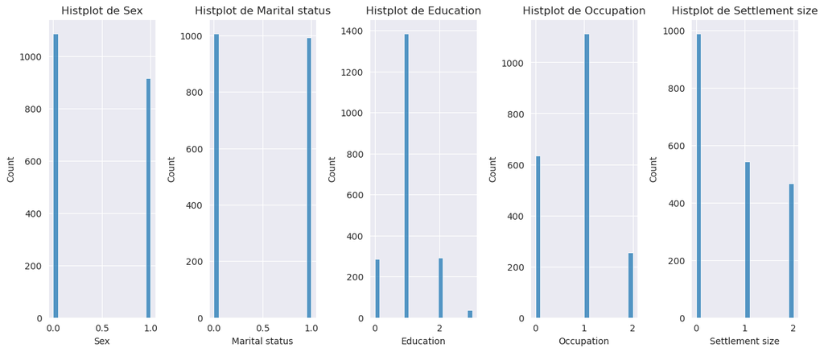

```python
# Tamanho da figura
plt.figure(1 , figsize = (15 , 6))

# Inicializa o contador
n = 0

# Loop pelas colunas
for x in ['Sex' , 'Marital status' , 'Education', 'Occupation', 'Settlement size']:
    n += 1
    plt.subplot(1 , 5 , n)
    plt.subplots_adjust(hspace = 0.5 , wspace = 0.5)
    sns.histplot(df[x], bins = 20)
    plt.title('Histplot de {}'.format(x))
plt.show()
```

Vamos vizualizar melhor os gráficos de Educação, Ocupação e Tamanho do assentamento

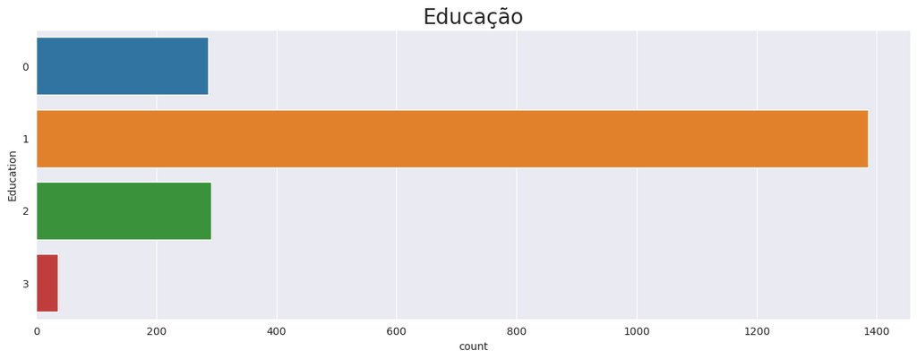

```python
plt.figure(1 , figsize = (15 , 5))
sns.countplot(y = 'Education' , data = df)
plt.title('Educação', fontsize = 20)
plt.show()
```

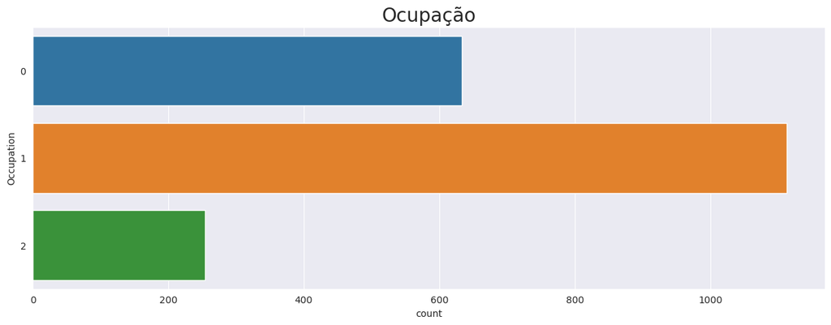

```python
plt.figure(1 , figsize = (15 , 5))
sns.countplot(y = 'Occupation' , data = df)
plt.title('Ocupação', fontsize = 20)
plt.show()
```

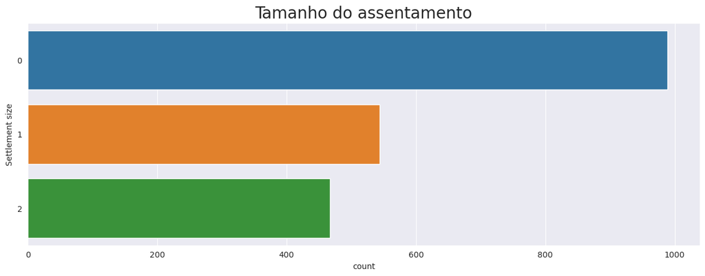

```python
plt.figure(1 , figsize = (15 , 5))
sns.countplot(y = 'Settlement size' , data = df)
plt.title('Tamanho do assentamento', fontsize = 20)
plt.show()
```

### Vamos visualizar a distribuição das variável Income

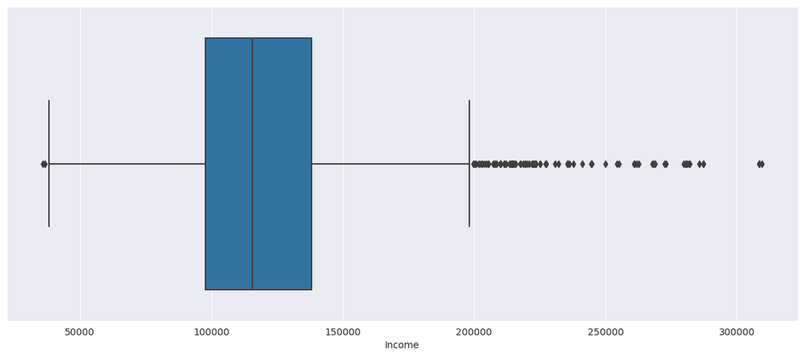

```python
plt.figure(1 , figsize = (15 , 6))
sns.boxplot(x = 'Income' , data = df)
```

### Retirando a variável ID, pois não será utilizada

```python
df = df.drop(['ID'], axis=1)
```

```python
df.head()
```

|  | index | Sex | Marital status | Age | Education | Income | Occupation | Settlement size |
| --- | --- | --- | --- | --- | --- | --- | --- | --- |
| 0 | 0 | 0 | 0 | 67 | 2 | 124670 | 1 | 2 |
| 1 | 1 | 1 | 1 | 22 | 1 | 150773 | 1 | 2 |
| 2 | 2 | 0 | 0 | 49 | 1 | 89210 | 0 | 0 |
| 3 | 3 | 0 | 0 | 45 | 1 | 171565 | 1 | 1 |
| 4 | 4 | 0 | 0 | 53 | 1 | 149031 | 1 | 1 |

## Começando a segmentação

### Segmentação 1

Para a primeira segmentação, usaremos a variável Marital status e a variável Education.

### Encontrando o valor ideal de Clusters

Vamos usar o método Elbow para encontrar o valor ideal de clusters. Vamos testar diferentes valores de K (valores de cluster) entre 2 e 6.

```python
X1 = df[['Marital status', 'Education']].iloc[:, :].values

inertia = []
```

```python
for n in range(2, 7):
    modelo = (KMeans(n_clusters = n,
                     init = 'k-means++',
                     n_init = 10,
                     max_iter = 300,
                     tol = 0.0001,
                     random_state = 102,
                     algorithm = 'elkan'))
    modelo.fit(X1)
    inertia.append(modelo.inertia_)
```

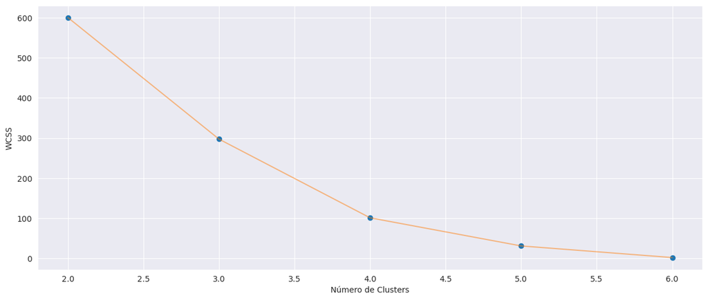

```python
plt.figure(1 , figsize = (15 ,6))
plt.plot(np.arange(2 , 7) , inertia , 'o')
plt.plot(np.arange(2 , 7) , inertia , '-' , alpha = 0.5)
plt.xlabel('Número de Clusters') , plt.ylabel('WCSS')
plt.show()
```

Vamos escolhemos o valor ideal de clusters para criar o modelo final para a Segmentação 1.

Normalmente usamos a quantidade de clusters que nos dará o menor WCSS, mas isso deve ser alinhado com as necessidade de negócio. Vamos começar com 2 clusters e avaliar e interpretar os resultados.

```python
modelo_seg1 = KMeans(n_clusters = 2,
                     init = 'k-means++',
                     n_init = 10,
                     max_iter = 300,
                     tol = 0.0001,
                     algorithm = 'elkan')
```

```python
modelo_seg1.fit(X1)
```

```
KMeans(algorithm='elkan', n_clusters=2, n_init=10)
```

Extraindo os labels e os centróides

```python
labels1 = modelo_seg1.labels_
centroids1 = modelo_seg1.cluster_centers_
```

### Segmentação 1 - Visualização e Interpretação dos Clusters

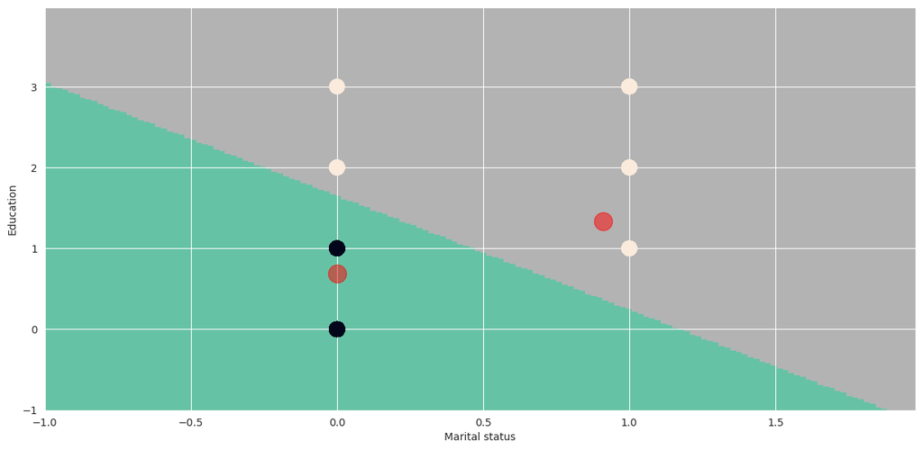

```python
h = 0.02
x_min, x_max = X1[:, 0].min() - 1, X1[:, 0].max() + 1
y_min, y_max = X1[:, 1].min() - 1, X1[:, 1].max() + 1
xx, yy = np.meshgrid(np.arange(x_min, x_max, h), np.arange(y_min, y_max, h))
Z = modelo_seg1.predict(np.c_[xx.ravel(), yy.ravel()])
plt.figure(1 , figsize = (15, 7) )
plt.clf()
Z = Z.reshape(xx.shape)

# Plot da imagem
plt.imshow(Z,
           interpolation = 'nearest',
           extent = (xx.min(), xx.max(), yy.min(), yy.max()),
           cmap = plt.cm.Set2,
           aspect = 'auto',
           origin = 'lower')

# Plot dos pontos de dados
plt.scatter( x = 'Marital status', y = 'Education', data = df, c = labels1, s = 200 )
plt.scatter(x = centroids1[: , 0], y =  centroids1[: , 1], s = 300, c = 'red', alpha = 0.5)
plt.xlabel('Marital status')
plt.ylabel('Education')
plt.show()
```

### Segmentação 2

Para a segunda segmentação, usaremos a variável Occupation e a variável Settlement size.

```python
X1 = df[['Occupation', 'Settlement size']].iloc[:, :].values

inertia = []
```

```python
for n in range(2, 7):
    modelo = (KMeans(n_clusters=n,
                     init='k-means++',
                     n_init=10,
                     max_iter=300,
                     tol=0.0001,
                     random_state=102,
                     algorithm='elkan'))
    modelo.fit(X1)
    inertia.append(modelo.inertia_)
```

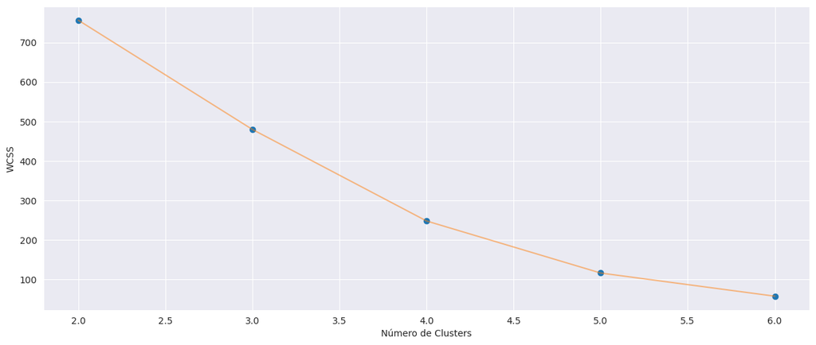

```python
plt.figure(1, figsize=(15, 6))
plt.plot(np.arange(2, 7), inertia, 'o')
plt.plot(np.arange(2, 7), inertia, '-', alpha=0.5)
plt.xlabel('Número de Clusters'), plt.ylabel('WCSS')
plt.show()
```

Vamos realizar esta segmentação com 3 clusters.

```python
modelo_seg1 = KMeans(n_clusters=3,
                     init='k-means++',
                     n_init=10,
                     max_iter=300,
                     tol=0.0001,
                     algorithm='elkan')
modelo_seg1.fit(X1)
```

```
KMeans(algorithm='elkan', n_clusters=3, n_init=10)
```

Extraindo os labels e os centróides

```python
labels1 = modelo_seg1.labels_
centroids1 = modelo_seg1.cluster_centers_
```

### Segmentação 2 - Visualização e Interpretação dos Clusters

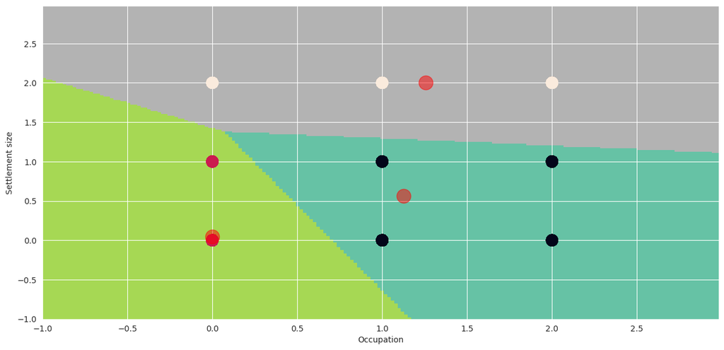

```python
h = 0.02
x_min, x_max = X1[:, 0].min() - 1, X1[:, 0].max() + 1
y_min, y_max = X1[:, 1].min() - 1, X1[:, 1].max() + 1
xx, yy = np.meshgrid(np.arange(x_min, x_max, h), np.arange(y_min, y_max, h))
Z = modelo_seg1.predict(np.c_[xx.ravel(), yy.ravel()])
plt.figure(1 , figsize = (15, 7) )
plt.clf()
Z = Z.reshape(xx.shape)

# Plot da imagem
plt.imshow(Z,
           interpolation = 'nearest',
           extent = (xx.min(), xx.max(), yy.min(), yy.max()),
           cmap = plt.cm.Set2,
           aspect = 'auto',
           origin = 'lower')

# Plot dos pontos de dados
plt.scatter( x = 'Occupation', y = 'Settlement size', data = df, c = labels1, s = 200 )
plt.scatter(x = centroids1[: , 0], y =  centroids1[: , 1], s = 300, c = 'red', alpha = 0.5)
plt.xlabel('Occupation')
plt.ylabel('Settlement size')
plt.show()
```

### Segmentação 2 - Interpretação dos Clusters

**Interpretação**:

- O ponto vermelho é o centróide de cada cluster (segmento).
- No cluster 1 (área em verde claro) temos clientes desempregados, que vivem em cidades pequenas e médias.
- No cluster 2 (área em verde escuro) temos clientes com que são funcionários qualificados, gerentes e autônomos, que moram em cidades pequenas e médias.
- No cluster 3 (área em cinza) temos clientes que estão tanto desempregados quanto com empregos de qualquer tipo, mas que vivem somente em cidades grandes.

### Segmentação 3

Vamos realizar mais uma segmentação de clientes, dessa vez utilizando a variável Sex e a variável Settlement size

```python
X1 = df[['Sex', 'Settlement size']].iloc[:, :].values

inertia = []
```

```python
for n in range(2, 7):
    modelo = (KMeans(n_clusters=n,
                     init='k-means++',
                     n_init=10,
                     max_iter=300,
                     tol=0.0001,
                     random_state=102,
                     algorithm='elkan'))
    modelo.fit(X1)
    inertia.append(modelo.inertia_)
```

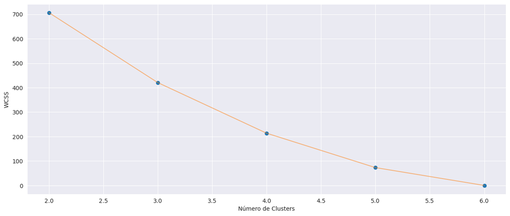

```python
plt.figure(1, figsize=(15, 6))
plt.plot(np.arange(2, 7), inertia, 'o')
plt.plot(np.arange(2, 7), inertia, '-', alpha=0.5)
plt.xlabel('Número de Clusters'), plt.ylabel('WCSS')
plt.show()
```

Vamos realizar esta segmentação com 4 clusters.

```python
modelo_seg1 = KMeans(n_clusters=4,
                     init='k-means++',
                     n_init=10,
                     max_iter=300,
                     tol=0.0001,
                     algorithm='elkan')
modelo_seg1.fit(X1)
```

```
KMeans(algorithm='elkan', n_clusters=4, n_init=10)
```

```python
labels1 = modelo_seg1.labels_
centroids1 = modelo_seg1.cluster_centers_
```

### Segmentação 3 - Visualização e Interpretação dos Clusters

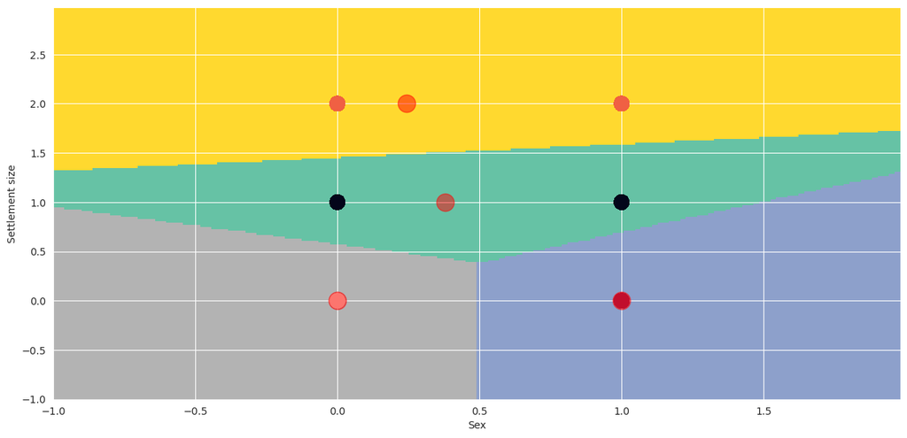

```python
h = 0.02
x_min, x_max = X1[:, 0].min() - 1, X1[:, 0].max() + 1
y_min, y_max = X1[:, 1].min() - 1, X1[:, 1].max() + 1
xx, yy = np.meshgrid(np.arange(x_min, x_max, h), np.arange(y_min, y_max, h))
Z = modelo_seg1.predict(np.c_[xx.ravel(), yy.ravel()])
plt.figure(1 , figsize = (15, 7) )
plt.clf()
Z = Z.reshape(xx.shape)

# Plot da imagem
plt.imshow(Z,
           interpolation = 'nearest',
           extent = (xx.min(), xx.max(), yy.min(), yy.max()),
           cmap = plt.cm.Set2,
           aspect = 'auto',
           origin = 'lower')

# Plot dos pontos de dados
plt.scatter( x = 'Sex', y = 'Settlement size', data = df, c = labels1, s = 200 )
plt.scatter(x = centroids1[: , 0], y =  centroids1[: , 1], s = 300, c = 'red', alpha = 0.5)
plt.xlabel('Sex')
plt.ylabel('Settlement size')
plt.show()
```

### Segmentação 3 - Interpretação dos Cluster

**Interpretação**:

- O ponto vermelho é o centróide de cada cluster (segmento).
- No cluster 1 (área em cinza) temos clientes do sexo masculino que vivem em cidades pequenas.
- No cluster 2 (área em azul) temos clientes do sexo feminino que vivem em cidades pequenas.
- No cluster 3 (área em verde) temos clientes de ambos os sexos que vivem em cidades médias.
- No cluster 4 (área em amarelo) temos clientes de ambos os sexos que vivem em cidades grandes.

## Conclusão

#### Ainda teriam muitas análises que poderíamos realizar. Realizamos segmentações apenas com duas variáveis por vez para conseguirmos interpretar o gráfico 2d. Segmentações com três variáveis poderiam ser realizadas, mas a interpretação de um gráfico 3d fica mais complexa.

#### Realizamos boas segmentações de clientes que possuem fácil interpretabilidade. Poderíamos agora enviar esses relatórios para a área de Marketing para que eles pudessem realizar campanhas mais direcionadas para cada segmento.